# Part II - (Prosper Loan Data Exploration)

## by (Lawrence Appiah-Nuamah)

> I am very much interest to find out what features or factors that affect a loan's outcome status?

## Investigation Overview

> Currently, I am looking at these features: Occupation, BorrowerStatus, IncomeRange, AvailableBankCardCredit, LoanOriginalAmount, EmploymentStatus, EmploymentStatusDuration, BorrowerRate, StatedMonthlyIncome, DebtToIncomeRatio,Term, BorrowerAPR,and LoanNumber as an index.

## Dataset Overview

> This document explores a dataset containing approximately 56000 Loans of people and with about 81 variables such as the borrower rate (or interest rate), current loan status, borrower income, loan amount and many others.

## (BorrowerAPR vs LoanStatus)

> This is to investigate if the Interest Rate (BorrowerAPR) affect the outcome of the Loan thus the LoanStatus

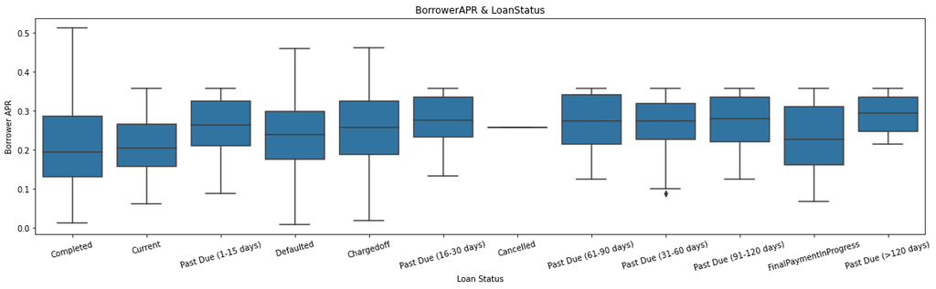

On BorrowerAPR vs LoanStatus graph we notice that Current and completed loans have lower rate than the past-due loans and have lower mean.

## (LenderYield vs Borrower APR vs ProsperRating)

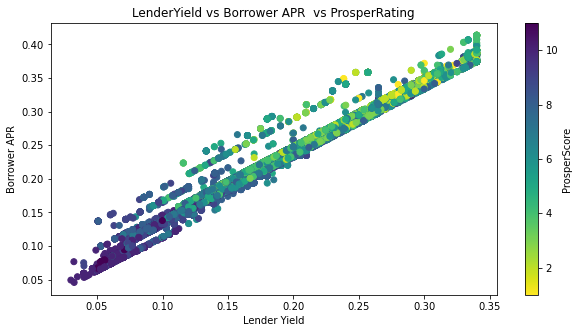

We can see that the relationship between all variables are clear. Borrower APR and Lender yield are directly positively correlated as when the interest borrowers pays more , the lender yield will increase. Higher the prosper score lower will lower borrower apr and then the lender yield will also be lower.

## (Borrower APR vs Employment status)

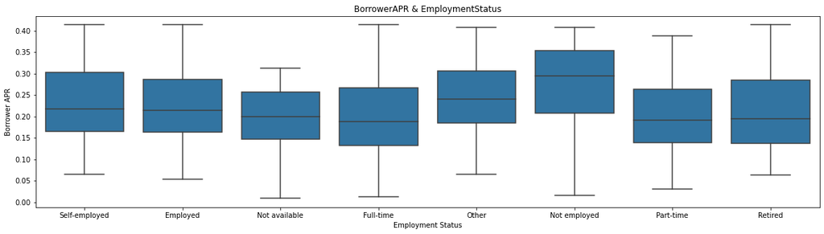

- On BorrowerAPR vs LoanStatus graph we notice that Current and completed loans have lower rate than the past-due loans and have lower mean.
- On BorrowerAPR vs Employment status graph we notice that Employed people have lower IQR than not employed.

## (Borrower APR vs Loan Category)

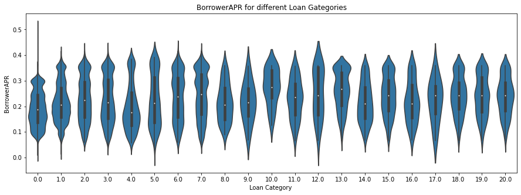

- We can see that Cosmetic Procedure are given higer interest rates with data distributed well in it.
- Listing Category: The category of the listing that the borrower selected when posting their listing: 0 - Not Available, 1 - Debt Consolidation, 2 - Home Improvement, 3 - Business, 4 - Personal Loan, 5 - Student Use, 6 - Auto, 7- Other, 8 - Baby&Adoption, 9 - Boat, 10 - Cosmetic Procedure, 11 - Engagement Ring, 12 - Green Loans, 13 - Household Expenses, 14 - Large Purchases, 15 - Medical/Dental, 16 - Motorcycle, 17 - RV, 18 - Taxes, 19 - Vacation, 20 - Wedding Loans

## (LoanStatus Vs BorrowerAPR in each EmploymentStatus)

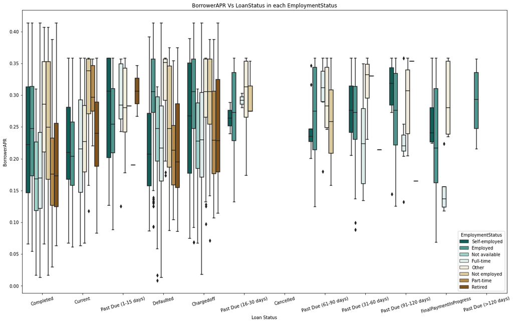